# Module08 Homework

Ethan Gutknecht

5/1/2022

# Question 1:

**A researcher is interested in studying the effect of Nitrogen oxides (NOX) on the mortality rate of some species. The data reside in a csv sheet Pollution. The variables we will consider in the dataset are MORT and NOX.**

#### Part I:

**Create a residual plot of (X,e) and a normal QQ plot of residual. Comment any assumption violations of simple linear regression.**

```r
library(tidyverse)
```

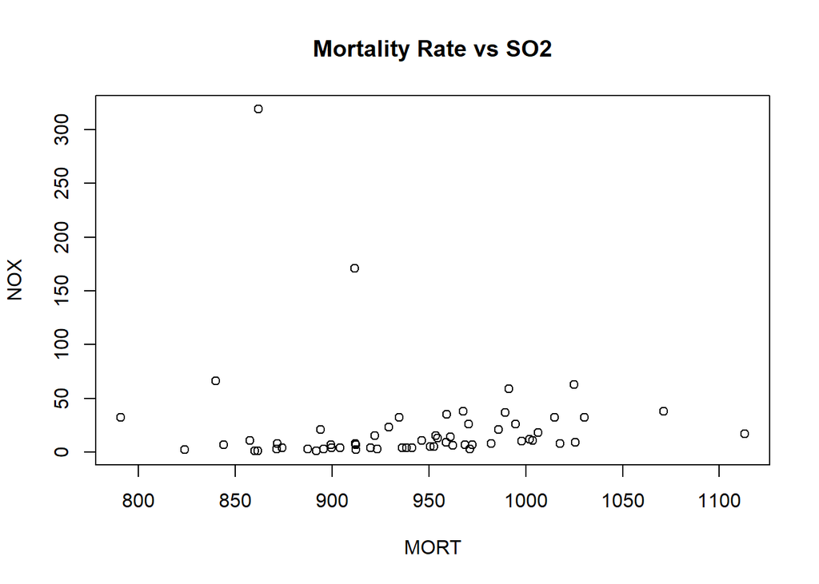

```r
Pollution <- read.csv("Pollution.csv", header = TRUE)

plot(NOX~MORT, data = Pollution, main ="Mortality Rate vs SO2")
```

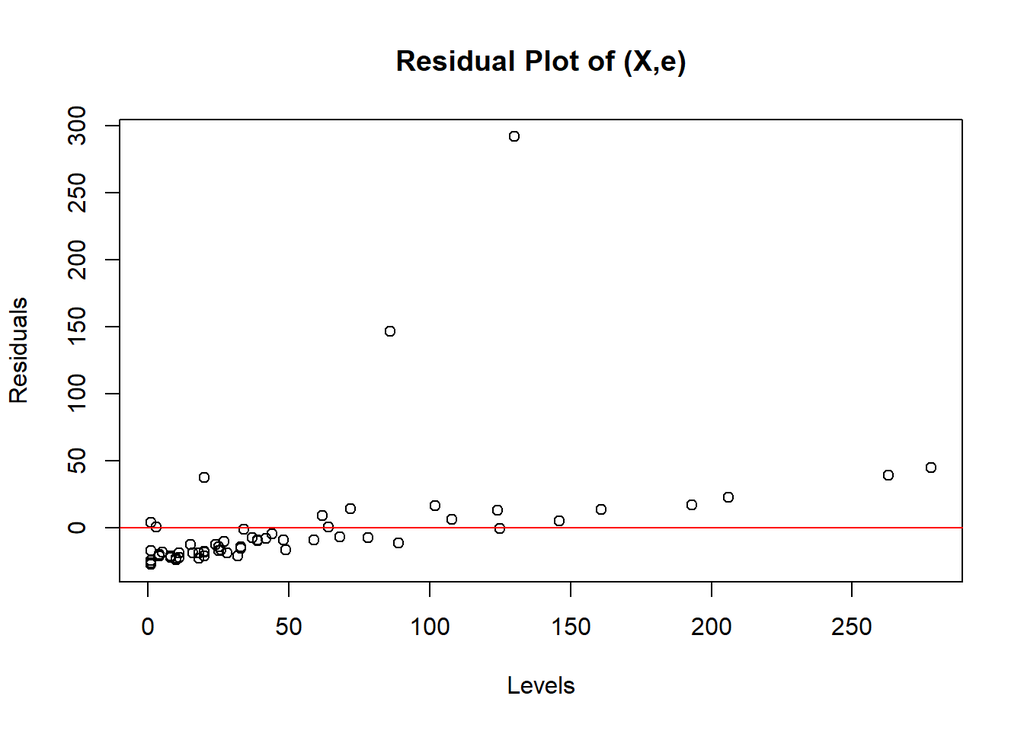

```r
X <- Pollution$SO2
fit <- lm(NOX~MORT, data = Pollution)
e <- resid(fit)
plot(X,e,ylab = "Residuals", xlab="Levels", main="Residual Plot of (X,e)")
abline(0,0, col = "Red")
```

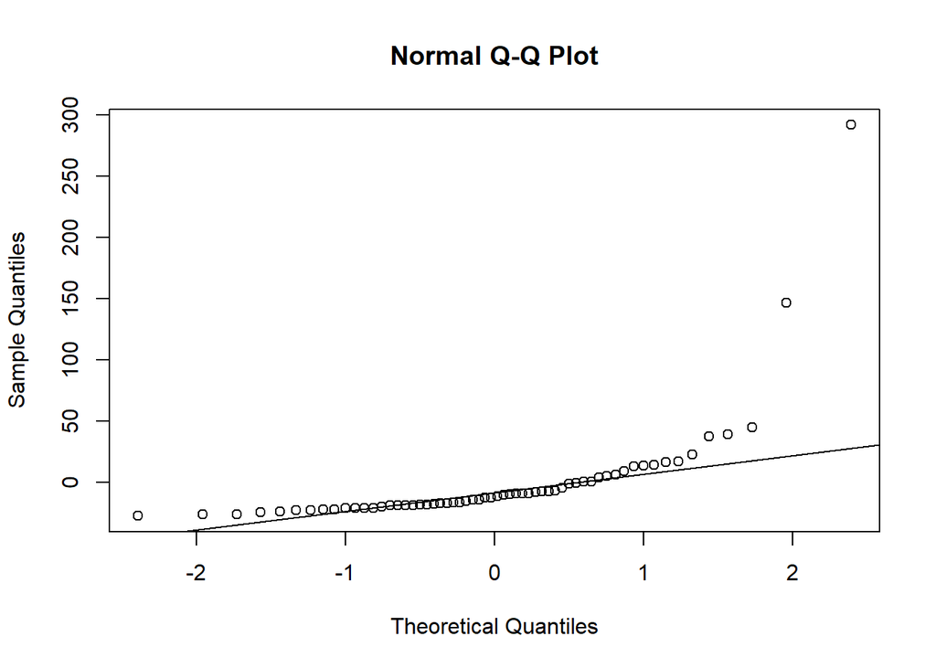

```r
qqnorm(e)
qqline(e)
```

#### Part II:

**Fit a nonparametric LOESS regression curve to the data, and use it to calculate a 95% bootstrap confidence interval for the true mean mortality rate for some species with NOX level 4. Interpret the bootstrap confidence interval for the true mean mortality rate for some species with NOX level 4.**

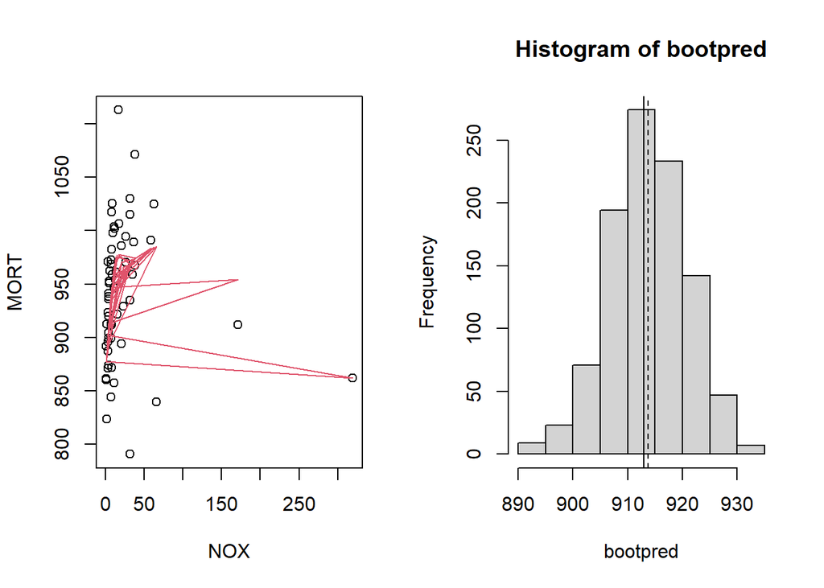

```r
par(mfrow=c(1,2)) # set up two panels for our plots
bootpred <- numeric(1000) # create vector to hold bootstrapped predictions
hyp.nox <- 4 # set the hypothesized x value for prediction
rate.lo <- loess(MORT~NOX, data = Pollution)
pred <- predict(rate.lo, data.frame(NOX = hyp.nox))

plot(MORT~NOX, data = Pollution) # make scatterplot of the data points
lines(Pollution$NOX, rate.lo$fit, col=2) # draw in the fitted loess curve
for (i in 1:1000) {
  n <- nrow(Pollution)
  index <- sample(1:n, size=n, replace=TRUE)
  bootdata<- data.frame(Mort=Pollution$MORT[index],NOX=Pollution$NOX[index])
  bootfit <- loess(Mort~NOX, bootdata)
  bootpred[i] <- predict(bootfit, data.frame(NOX = hyp.nox))
} # extract predicted rate when age=12

hist(bootpred) # picture of the bootstrap dist of predictions
abline(v=pred) # add vertical line at the actual sample prediction
abline(v=mean(bootpred),lty=2) # add dashed line at mean of the bootstrap distribution
```

```r
quantile(bootpred, c(0.025, 0.975)) # bootstrap CI for prediction
```

```
##     2.5%    97.5%
## 898.6463 927.3238
```

We are 95% confident that the mean mortality rate for spcies when NOX levels are at 4 is between 898.6463 and 927.3238.

#### Part III:

**Generate a picture of the bootstrapped LOESS curves**

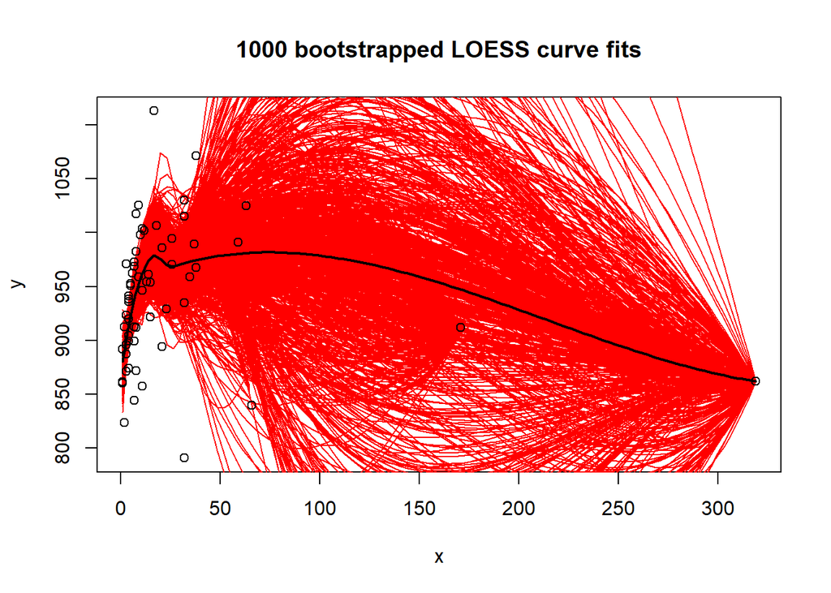

```r
x <- Pollution$NOX
y <- Pollution$MORT
out <- loess(y~x, span = 0.9)
plot(y~x, main="1000 bootstrapped LOESS curve fits")
curve(predict(out, newdata=data.frame(x = x)), add=TRUE)
n <- length(x)

nboot <- 1000
for (i in 1:nboot) {
  index <- sample(n, replace = TRUE)
  boot.x <- x[index]
  boot.y <- y[index]
  boot.out <- loess(boot.y~boot.x, span=0.75)
  curve(predict(boot.out, data.frame(boot.x = x)), add=TRUE, col="red")
}
points(x, y)
curve(predict(out, newdata=data.frame(x = x)), add=TRUE, lwd=2)
```

#### Part IV:

**Find the same prediction (i.e. a 95% CI for the true mean mortality rate for some species with NOX level 4), only now using a conventional simple linear regression. How does the result compare to your bootstrap CI found from a LOESS model?**

```r
slrfit <- lm(MORT~NOX, data = Pollution)
predict(slrfit, newdata=data.frame(NOX=4), int="conf")
```

```
##        fit      lwr      upr
## 1 942.2674 924.8006 959.7343
```

The simple linear regression yields a 95% confidence interval for the true mean mortality rate of some species (924.8006 959.7343) that was exposed to Nitrogen Oxides. The LOESS model with bootstrapping yielded (898.6463 927.3238) which means that the SLR model is overestimating the response at this point by a small amount.